# Trabajo individual de FAEDE+AEDM

#### c. Obtén el número de individuos y de qué grupo están incluidos en cada uno de los conglomerados obtenidos.

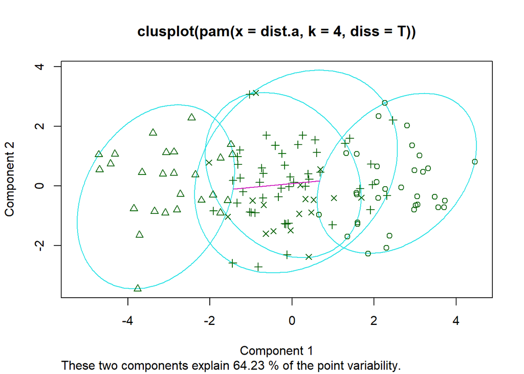

```r
# Cuando trabajamos con todos los datos

kmed_all <- pam(dist.a, k=4, diss=T)
plot(kmed_all,which.plots=1)
```

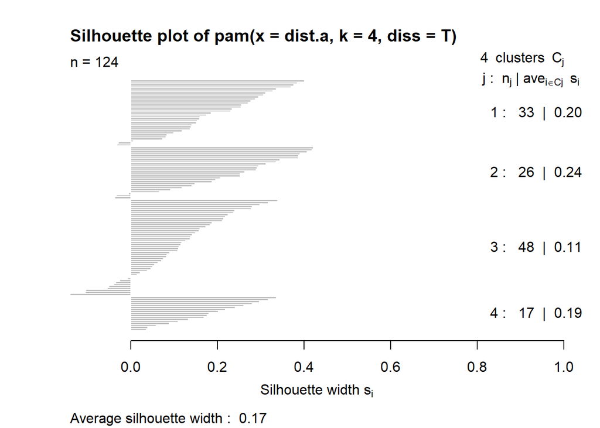

```r
plot(kmed_all)
```

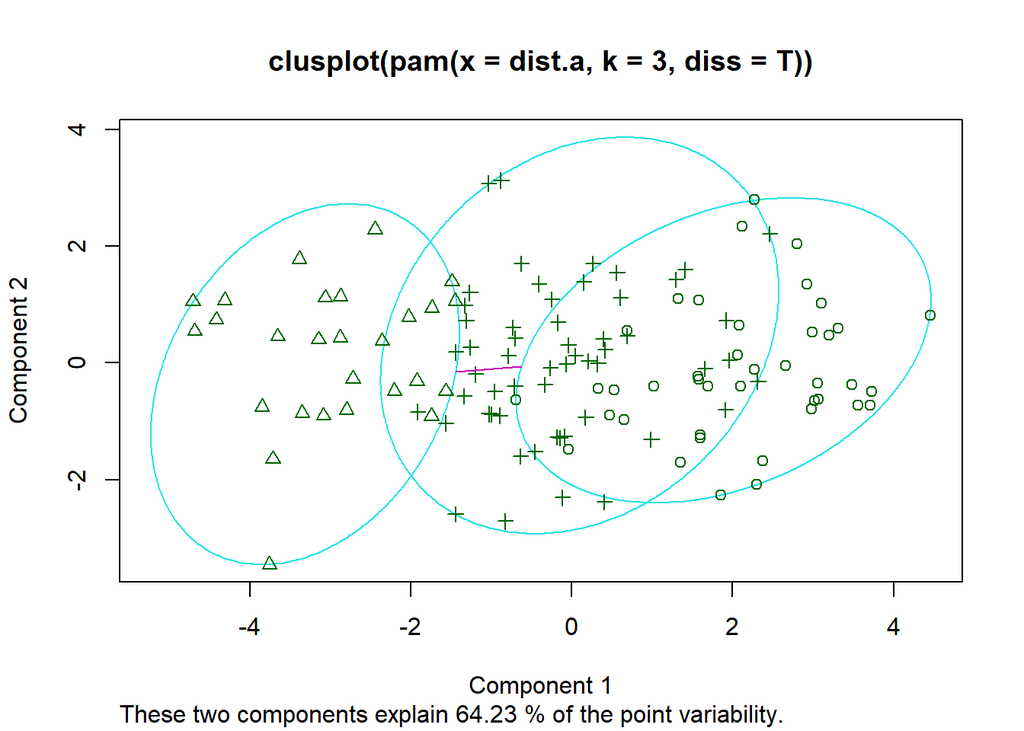

```r
#Cuando trabajamos con los 6 primeros componentes principales


kmed.comp <- pam(dist.a, k=3, diss=T)
plot(kmed.comp,which.plots=1)
```

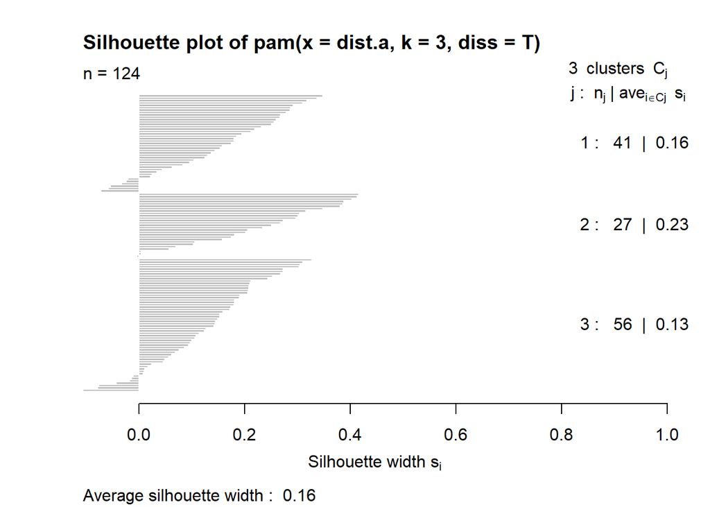

```r
plot(kmed.comp)
```

En el análisis con 4 clusters. El primer cluster tiene 33 muestras, el segundo 26, el tercero 48 y el último 17 muestras. Atendiendo al análisis con 3 clusters, cada uno tiene el siguiente número de muestras: 41,27 y 56.

Podemos interpretar las gráficas de la siguiente manera:

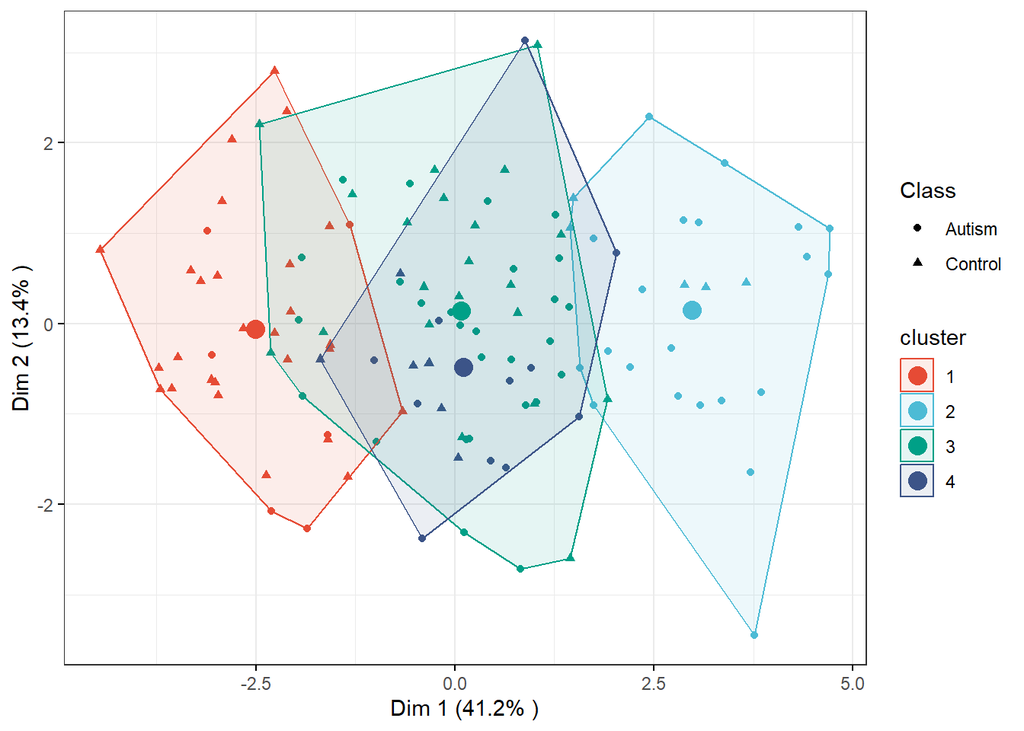

```r
# Coordinates of individuals
ind.coord <- as.data.frame(get_pca_ind(a.pca)$coord)
# Add clusters obtained using the K-means algorithm
ind.coord$cluster <- factor(kmed_all$clustering)
# Add Species groups from the original data sett
ind.coord$Class <- datos_reorg$Class


# Percentage of variance explained by dimensions
eigenvalue <- as_data_frame(round(get_eigenvalue(a.pca), 1))
variance.percent <- eigenvalue$variance.percent


ggscatter(
  ind.coord, x = "Dim.1", y = "Dim.2",
  color = "cluster", palette = "npg", ellipse = TRUE, ellipse.type = "convex",
  shape = "Class", size = 1.5,  legend = "right", ggtheme = theme_bw(),
  xlab = paste0("Dim 1 (", variance.percent[1], "% )" ),
  ylab = paste0("Dim 2 (", variance.percent[2], "% )" )
) +
  stat_mean(aes(color = cluster), size = 4)
```

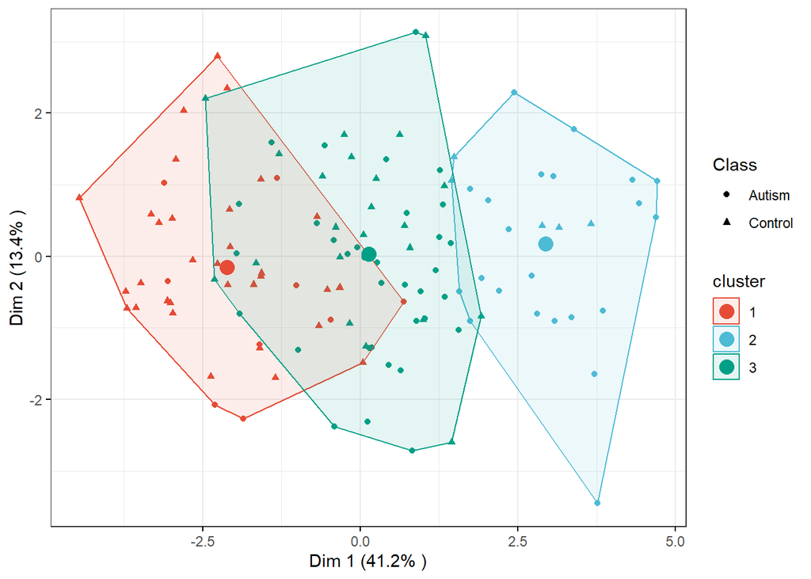

```r
# Coordinates of individuals
ind.coord <- as.data.frame(get_pca_ind(a.pca)$coord)
# Add clusters obtained using the K-means algorithm
ind.coord$cluster <- factor(kmed.comp$clustering)
# Add Species groups from the original data sett
ind.coord$Class <- datos_reorg$Class



# Percentage of variance explained by dimensions
eigenvalue <- as_data_frame(round(get_eigenvalue(a.pca), 1))
variance.percent <- eigenvalue$variance.percent


ggscatter(
  ind.coord, x = "Dim.1", y = "Dim.2",
  color = "cluster", palette = "npg", ellipse = TRUE, ellipse.type = "convex",
  shape = "Class", size = 1.5,  legend = "right", ggtheme = theme_bw(),
  xlab = paste0("Dim 1 (", variance.percent[1], "% )" ),
  ylab = paste0("Dim 2 (", variance.percent[2], "% )" )
) +
  stat_mean(aes(color = cluster), size = 4)
```